# Risk Factor Analysis

## Outcome Variable

**Outcome Variable:** stunted

## Predictor Variables

**Intervention Variable:** tr

**Adjustment Set:**

unadjusted

## Stratifying Variables

The analysis was stratified on these variable(s):

- fhtcm
- agecat
- studyid
- country

## Data Summary

| fhtcm | agecat | studyid | country | tr | stunted | n_cell | n |
| --- | --- | --- | --- | --- | --- | --- | --- |
| <160 | 6 months | ki1000304b-SAS-CompFeed | INDIA | Control | 0 | 12 | 37 |
| <160 | 6 months | ki1000304b-SAS-CompFeed | INDIA | Control | 1 | 5 | 37 |
| <160 | 6 months | ki1000304b-SAS-CompFeed | INDIA | Other | 0 | 10 | 37 |
| <160 | 6 months | ki1000304b-SAS-CompFeed | INDIA | Other | 1 | 10 | 37 |
| >=170 | 6 months | ki1000304b-SAS-CompFeed | INDIA | Control | 0 | 35 | 88 |
| >=170 | 6 months | ki1000304b-SAS-CompFeed | INDIA | Control | 1 | 6 | 88 |
| >=170 | 6 months | ki1000304b-SAS-CompFeed | INDIA | Other | 0 | 35 | 88 |
| >=170 | 6 months | ki1000304b-SAS-CompFeed | INDIA | Other | 1 | 12 | 88 |
| [160-170) | 6 months | ki1000304b-SAS-CompFeed | INDIA | Control | 0 | 70 | 184 |
| [160-170) | 6 months | ki1000304b-SAS-CompFeed | INDIA | Control | 1 | 22 | 184 |
| [160-170) | 6 months | ki1000304b-SAS-CompFeed | INDIA | Other | 0 | 59 | 184 |
| [160-170) | 6 months | ki1000304b-SAS-CompFeed | INDIA | Other | 1 | 33 | 184 |
| [160-170) | Birth | ki1000304b-SAS-CompFeed | INDIA | Control | 0 | 23 | 49 |
| [160-170) | Birth | ki1000304b-SAS-CompFeed | INDIA | Control | 1 | 7 | 49 |
| [160-170) | Birth | ki1000304b-SAS-CompFeed | INDIA | Other | 0 | 14 | 49 |
| [160-170) | Birth | ki1000304b-SAS-CompFeed | INDIA | Other | 1 | 5 | 49 |
| <160 | Birth | ki1000304b-SAS-CompFeed | INDIA | Control | 0 | 4 | 8 |
| <160 | Birth | ki1000304b-SAS-CompFeed | INDIA | Control | 1 | 2 | 8 |
| <160 | Birth | ki1000304b-SAS-CompFeed | INDIA | Other | 0 | 0 | 8 |
| <160 | Birth | ki1000304b-SAS-CompFeed | INDIA | Other | 1 | 2 | 8 |
| >=170 | Birth | ki1000304b-SAS-CompFeed | INDIA | Control | 0 | 3 | 11 |
| >=170 | Birth | ki1000304b-SAS-CompFeed | INDIA | Control | 1 | 3 | 11 |
| >=170 | Birth | ki1000304b-SAS-CompFeed | INDIA | Other | 0 | 3 | 11 |
| >=170 | Birth | ki1000304b-SAS-CompFeed | INDIA | Other | 1 | 2 | 11 |
| <160 | 6 months | ki1000304b-SAS-FoodSuppl | INDIA | Control | 0 | 9 | 88 |
| <160 | 6 months | ki1000304b-SAS-FoodSuppl | INDIA | Control | 1 | 13 | 88 |
| <160 | 6 months | ki1000304b-SAS-FoodSuppl | INDIA | Other | 0 | 34 | 88 |
| <160 | 6 months | ki1000304b-SAS-FoodSuppl | INDIA | Other | 1 | 32 | 88 |
| [160-170) | 6 months | ki1000304b-SAS-FoodSuppl | INDIA | Control | 0 | 28 | 207 |
| [160-170) | 6 months | ki1000304b-SAS-FoodSuppl | INDIA | Control | 1 | 27 | 207 |

[output cut: 76 more lines]

The following strata were considered:

- fhtcm: [160-170), agecat: 24 months, studyid: ki1119695-PROBIT, country: BELARUS
- fhtcm: [160-170), agecat: 24 months, studyid: ki1135781-COHORTS, country: GUATEMALA
- fhtcm: [160-170), agecat: 6 months, studyid: ki1000304b-SAS-CompFeed, country: INDIA
- fhtcm: [160-170), agecat: 6 months, studyid: ki1000304b-SAS-FoodSuppl, country: INDIA
- fhtcm: [160-170), agecat: 6 months, studyid: ki1119695-PROBIT, country: BELARUS
- fhtcm: [160-170), agecat: 6 months, studyid: ki1135781-COHORTS, country: GUATEMALA
- fhtcm: [160-170), agecat: Birth, studyid: ki1000304b-SAS-CompFeed, country: INDIA
- fhtcm: [160-170), agecat: Birth, studyid: ki1119695-PROBIT, country: BELARUS
- fhtcm: [160-170), agecat: Birth, studyid: ki1135781-COHORTS, country: GUATEMALA
- fhtcm: <160, agecat: 24 months, studyid: ki1119695-PROBIT, country: BELARUS
- fhtcm: <160, agecat: 24 months, studyid: ki1135781-COHORTS, country: GUATEMALA
- fhtcm: <160, agecat: 6 months, studyid: ki1000304b-SAS-CompFeed, country: INDIA
- fhtcm: <160, agecat: 6 months, studyid: ki1000304b-SAS-FoodSuppl, country: INDIA
- fhtcm: <160, agecat: 6 months, studyid: ki1119695-PROBIT, country: BELARUS
- fhtcm: <160, agecat: 6 months, studyid: ki1135781-COHORTS, country: GUATEMALA
- fhtcm: <160, agecat: Birth, studyid: ki1000304b-SAS-CompFeed, country: INDIA
- fhtcm: <160, agecat: Birth, studyid: ki1119695-PROBIT, country: BELARUS
- fhtcm: <160, agecat: Birth, studyid: ki1135781-COHORTS, country: GUATEMALA
- fhtcm: >=170, agecat: 24 months, studyid: ki1119695-PROBIT, country: BELARUS
- fhtcm: >=170, agecat: 24 months, studyid: ki1135781-COHORTS, country: GUATEMALA
- fhtcm: >=170, agecat: 6 months, studyid: ki1000304b-SAS-CompFeed, country: INDIA
- fhtcm: >=170, agecat: 6 months, studyid: ki1000304b-SAS-FoodSuppl, country: INDIA
- fhtcm: >=170, agecat: 6 months, studyid: ki1119695-PROBIT, country: BELARUS
- fhtcm: >=170, agecat: 6 months, studyid: ki1135781-COHORTS, country: GUATEMALA
- fhtcm: >=170, agecat: Birth, studyid: ki1000304b-SAS-CompFeed, country: INDIA
- fhtcm: >=170, agecat: Birth, studyid: ki1119695-PROBIT, country: BELARUS
- fhtcm: >=170, agecat: Birth, studyid: ki1135781-COHORTS, country: GUATEMALA

### Dropped Strata

Some strata were dropped due to rare outcomes:

- fhtcm: <160, agecat: Birth, studyid: ki1000304b-SAS-CompFeed, country: INDIA
- fhtcm: >=170, agecat: Birth, studyid: ki1000304b-SAS-CompFeed, country: INDIA
- fhtcm: [160-170), agecat: Birth, studyid: ki1119695-PROBIT, country: BELARUS
- fhtcm: <160, agecat: 6 months, studyid: ki1119695-PROBIT, country: BELARUS
- fhtcm: <160, agecat: 24 months, studyid: ki1119695-PROBIT, country: BELARUS
- fhtcm: [160-170), agecat: Birth, studyid: ki1135781-COHORTS, country: GUATEMALA
- fhtcm: <160, agecat: Birth, studyid: ki1135781-COHORTS, country: GUATEMALA
- fhtcm: >=170, agecat: 6 months, studyid: ki1135781-COHORTS, country: GUATEMALA
- fhtcm: >=170, agecat: Birth, studyid: ki1135781-COHORTS, country: GUATEMALA
- fhtcm: >=170, agecat: 24 months, studyid: ki1135781-COHORTS, country: GUATEMALA

## Methods Detail

We’re interested in the causal parameters $E[Y_a]$ for all values of $a \in \mathcal{A}$. These parameters represent the mean outcome if, possibly contrary to fact, we intervened to set all units to have $A=a$. Under the randomization and positivity assumptions, these are identified by the statistical parameters $\psi_a=E_W[E_{Y|A,W}(Y|A=a,W)]$. In addition, we’re interested in the mean of $Y$, $E[Y]$ under no intervention (the observed mean). We will estimate these parameters by using SuperLearner to fit the relevant likelihood factors – $E_{Y|A,W}(Y|A=a,W)$ and $p(A=a|W)$, and then updating our likelihood fit using a joint TMLE.

For unadjusted analyses ($W=\{\}$), initial likelihoods were estimated using Lrnr_glm to estimate the simple $E(Y|A)$ and Lrnr_mean to estimate $p(A)$. For adjusted analyses, a small library containing Lrnr_glmnet, Lrnr_xgboost, and Lrnr_mean was used.

Having estimated these parameters, we will then use the delta method to estimate relative risks and attributable risks relative to a prespecified baseline level of $A$.

[output not shown]

# Results Detail

## Results Plots

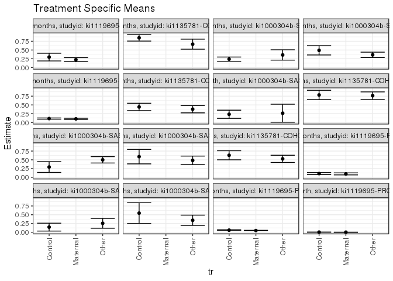

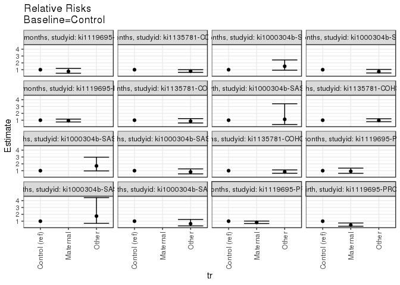

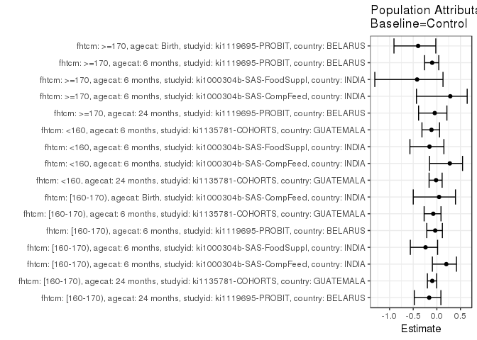

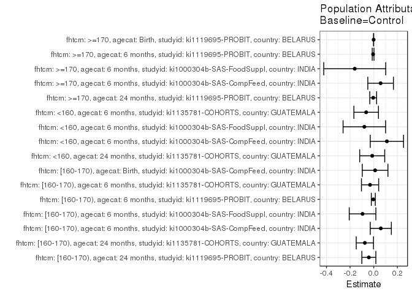

## Results Table

### Parameter: TSM

| fhtcm | agecat | studyid | country | intervention_level | baseline_level | estimate | ci_lower | ci_upper |
| --- | --- | --- | --- | --- | --- | --- | --- | --- |
| [160-170) | Birth | ki1000304b-SAS-CompFeed | INDIA | Control | NA | 0.2333333 | 0.1167358 | 0.3499308 |
| [160-170) | Birth | ki1000304b-SAS-CompFeed | INDIA | Other | NA | 0.2631579 | 0.0068293 | 0.5194864 |
| [160-170) | 6 months | ki1000304b-SAS-CompFeed | INDIA | Control | NA | 0.2391304 | 0.1787815 | 0.2994794 |
| [160-170) | 6 months | ki1000304b-SAS-CompFeed | INDIA | Other | NA | 0.3586957 | 0.2109733 | 0.5064180 |
| [160-170) | 6 months | ki1000304b-SAS-FoodSuppl | INDIA | Control | NA | 0.4909091 | 0.3584699 | 0.6233483 |
| [160-170) | 6 months | ki1000304b-SAS-FoodSuppl | INDIA | Other | NA | 0.3618421 | 0.2852646 | 0.4384197 |
| [160-170) | 6 months | ki1119695-PROBIT | BELARUS | Control | NA | 0.1102484 | 0.0927096 | 0.1277873 |
| [160-170) | 6 months | ki1119695-PROBIT | BELARUS | Maternal | NA | 0.1021898 | 0.0857014 | 0.1186782 |
| [160-170) | 6 months | ki1135781-COHORTS | GUATEMALA | Control | NA | 0.4418605 | 0.3365893 | 0.5471316 |
| [160-170) | 6 months | ki1135781-COHORTS | GUATEMALA | Other | NA | 0.3780488 | 0.2727824 | 0.4833152 |
| [160-170) | 24 months | ki1119695-PROBIT | BELARUS | Control | NA | 0.2972973 | 0.1876033 | 0.4069913 |
| [160-170) | 24 months | ki1119695-PROBIT | BELARUS | Maternal | NA | 0.2244898 | 0.1667581 | 0.2822215 |
| [160-170) | 24 months | ki1135781-COHORTS | GUATEMALA | Control | NA | 0.8474576 | 0.7552563 | 0.9396589 |
| [160-170) | 24 months | ki1135781-COHORTS | GUATEMALA | Other | NA | 0.6666667 | 0.5233892 | 0.8099441 |
| <160 | 6 months | ki1000304b-SAS-CompFeed | INDIA | Control | NA | 0.2941176 | 0.1400689 | 0.4481664 |
| <160 | 6 months | ki1000304b-SAS-CompFeed | INDIA | Other | NA | 0.5000000 | 0.4094529 | 0.5905471 |
| <160 | 6 months | ki1000304b-SAS-FoodSuppl | INDIA | Control | NA | 0.5909091 | 0.3842813 | 0.7975369 |
| <160 | 6 months | ki1000304b-SAS-FoodSuppl | INDIA | Other | NA | 0.4848485 | 0.3635855 | 0.6061115 |
| <160 | 6 months | ki1135781-COHORTS | GUATEMALA | Control | NA | 0.6296296 | 0.5003844 | 0.7588749 |
| <160 | 6 months | ki1135781-COHORTS | GUATEMALA | Other | NA | 0.5274725 | 0.4245421 | 0.6304029 |
| <160 | 24 months | ki1135781-COHORTS | GUATEMALA | Control | NA | 0.7837838 | 0.6504429 | 0.9171247 |
| <160 | 24 months | ki1135781-COHORTS | GUATEMALA | Other | NA | 0.7627119 | 0.6535894 | 0.8718343 |
| >=170 | Birth | ki1119695-PROBIT | BELARUS | Control | NA | 0.0032727 | 0.0020050 | 0.0045405 |
| >=170 | Birth | ki1119695-PROBIT | BELARUS | Maternal | NA | 0.0014306 | 0.0009283 | 0.0019329 |
| >=170 | 6 months | ki1000304b-SAS-CompFeed | INDIA | Control | NA | 0.1463415 | 0.0339059 | 0.2587770 |
| >=170 | 6 months | ki1000304b-SAS-CompFeed | INDIA | Other | NA | 0.2553191 | 0.1144312 | 0.3962071 |
| >=170 | 6 months | ki1000304b-SAS-FoodSuppl | INDIA | Control | NA | 0.5454545 | 0.2483315 | 0.8425775 |
| >=170 | 6 months | ki1000304b-SAS-FoodSuppl | INDIA | Other | NA | 0.3414634 | 0.1948969 | 0.4880299 |
| >=170 | 6 months | ki1119695-PROBIT | BELARUS | Control | NA | 0.0593255 | 0.0493558 | 0.0692951 |
| >=170 | 6 months | ki1119695-PROBIT | BELARUS | Maternal | NA | 0.0484710 | 0.0417064 | 0.0552355 |
| >=170 | 24 months | ki1119695-PROBIT | BELARUS | Control | NA | 0.1071429 | 0.0776400 | 0.1366457 |
| >=170 | 24 months | ki1119695-PROBIT | BELARUS | Maternal | NA | 0.0985916 | 0.0696600 | 0.1275231 |

### Parameter: E(Y)

| fhtcm | agecat | studyid | country | intervention_level | baseline_level | estimate | ci_lower | ci_upper |
| --- | --- | --- | --- | --- | --- | --- | --- | --- |
| [160-170) | Birth | ki1000304b-SAS-CompFeed | INDIA | NA | NA | 0.2448980 | 0.1219863 | 0.3678096 |
| [160-170) | 6 months | ki1000304b-SAS-CompFeed | INDIA | NA | NA | 0.2989130 | 0.2024636 | 0.3953625 |
| [160-170) | 6 months | ki1000304b-SAS-FoodSuppl | INDIA | NA | NA | 0.3961353 | 0.3293461 | 0.4629244 |
| [160-170) | 6 months | ki1119695-PROBIT | BELARUS | NA | NA | 0.1065436 | 0.0819256 | 0.1311616 |
| [160-170) | 6 months | ki1135781-COHORTS | GUATEMALA | NA | NA | 0.4107143 | 0.3360999 | 0.4853287 |
| [160-170) | 24 months | ki1119695-PROBIT | BELARUS | NA | NA | 0.2558140 | 0.1303350 | 0.3812930 |
| [160-170) | 24 months | ki1135781-COHORTS | GUATEMALA | NA | NA | 0.7722772 | 0.6900836 | 0.8544708 |
| <160 | 6 months | ki1000304b-SAS-CompFeed | INDIA | NA | NA | 0.4054054 | 0.2995645 | 0.5112463 |
| <160 | 6 months | ki1000304b-SAS-FoodSuppl | INDIA | NA | NA | 0.5113636 | 0.4063257 | 0.6164016 |
| <160 | 6 months | ki1135781-COHORTS | GUATEMALA | NA | NA | 0.5655172 | 0.4845562 | 0.6464783 |
| <160 | 24 months | ki1135781-COHORTS | GUATEMALA | NA | NA | 0.7708333 | 0.6863167 | 0.8553500 |
| >=170 | Birth | ki1119695-PROBIT | BELARUS | NA | NA | 0.0023440 | 0.0009149 | 0.0037732 |
| >=170 | 6 months | ki1000304b-SAS-CompFeed | INDIA | NA | NA | 0.2045455 | 0.1128702 | 0.2962207 |
| >=170 | 6 months | ki1000304b-SAS-FoodSuppl | INDIA | NA | NA | 0.3846154 | 0.2510944 | 0.5181364 |
| >=170 | 6 months | ki1119695-PROBIT | BELARUS | NA | NA | 0.0539624 | 0.0413738 | 0.0665510 |
| >=170 | 24 months | ki1119695-PROBIT | BELARUS | NA | NA | 0.1025641 | 0.0611143 | 0.1440139 |

### Parameter: RR

| fhtcm | agecat | studyid | country | intervention_level | baseline_level | estimate | ci_lower | ci_upper |
| --- | --- | --- | --- | --- | --- | --- | --- | --- |
| [160-170) | Birth | ki1000304b-SAS-CompFeed | INDIA | Control | Control | 1.0000000 | 1.0000000 | 1.0000000 |
| [160-170) | Birth | ki1000304b-SAS-CompFeed | INDIA | Other | Control | 1.1278195 | 0.3739101 | 3.4018256 |
| [160-170) | 6 months | ki1000304b-SAS-CompFeed | INDIA | Control | Control | 1.0000000 | 1.0000000 | 1.0000000 |
| [160-170) | 6 months | ki1000304b-SAS-CompFeed | INDIA | Other | Control | 1.5000000 | 0.9275770 | 2.4256747 |
| [160-170) | 6 months | ki1000304b-SAS-FoodSuppl | INDIA | Control | Control | 1.0000000 | 1.0000000 | 1.0000000 |
| [160-170) | 6 months | ki1000304b-SAS-FoodSuppl | INDIA | Other | Control | 0.7370858 | 0.5231234 | 1.0385608 |
| [160-170) | 6 months | ki1119695-PROBIT | BELARUS | Control | Control | 1.0000000 | 1.0000000 | 1.0000000 |
| [160-170) | 6 months | ki1119695-PROBIT | BELARUS | Maternal | Control | 0.9269045 | 0.7403970 | 1.1603936 |
| [160-170) | 6 months | ki1135781-COHORTS | GUATEMALA | Control | Control | 1.0000000 | 1.0000000 | 1.0000000 |
| [160-170) | 6 months | ki1135781-COHORTS | GUATEMALA | Other | Control | 0.8555841 | 0.5930768 | 1.2342821 |
| [160-170) | 24 months | ki1119695-PROBIT | BELARUS | Control | Control | 1.0000000 | 1.0000000 | 1.0000000 |
| [160-170) | 24 months | ki1119695-PROBIT | BELARUS | Maternal | Control | 0.7551020 | 0.4813212 | 1.1846125 |
| [160-170) | 24 months | ki1135781-COHORTS | GUATEMALA | Control | Control | 1.0000000 | 1.0000000 | 1.0000000 |
| [160-170) | 24 months | ki1135781-COHORTS | GUATEMALA | Other | Control | 0.7866667 | 0.6182661 | 1.0009354 |
| <160 | 6 months | ki1000304b-SAS-CompFeed | INDIA | Control | Control | 1.0000000 | 1.0000000 | 1.0000000 |
| <160 | 6 months | ki1000304b-SAS-CompFeed | INDIA | Other | Control | 1.7000000 | 0.9705710 | 2.9776286 |
| <160 | 6 months | ki1000304b-SAS-FoodSuppl | INDIA | Control | Control | 1.0000000 | 1.0000000 | 1.0000000 |
| <160 | 6 months | ki1000304b-SAS-FoodSuppl | INDIA | Other | Control | 0.8205128 | 0.5337963 | 1.2612325 |
| <160 | 6 months | ki1135781-COHORTS | GUATEMALA | Control | Control | 1.0000000 | 1.0000000 | 1.0000000 |
| <160 | 6 months | ki1135781-COHORTS | GUATEMALA | Other | Control | 0.8377505 | 0.6311203 | 1.1120319 |
| <160 | 24 months | ki1135781-COHORTS | GUATEMALA | Control | Control | 1.0000000 | 1.0000000 | 1.0000000 |
| <160 | 24 months | ki1135781-COHORTS | GUATEMALA | Other | Control | 0.9731151 | 0.7791586 | 1.2153535 |
| >=170 | Birth | ki1119695-PROBIT | BELARUS | Control | Control | 1.0000000 | 1.0000000 | 1.0000000 |
| >=170 | Birth | ki1119695-PROBIT | BELARUS | Maternal | Control | 0.4371324 | 0.2594423 | 0.7365213 |
| >=170 | 6 months | ki1000304b-SAS-CompFeed | INDIA | Control | Control | 1.0000000 | 1.0000000 | 1.0000000 |
| >=170 | 6 months | ki1000304b-SAS-CompFeed | INDIA | Other | Control | 1.7446809 | 0.6851435 | 4.4427355 |
| >=170 | 6 months | ki1000304b-SAS-FoodSuppl | INDIA | Control | Control | 1.0000000 | 1.0000000 | 1.0000000 |
| >=170 | 6 months | ki1000304b-SAS-FoodSuppl | INDIA | Other | Control | 0.6260163 | 0.3128926 | 1.2524946 |
| >=170 | 6 months | ki1119695-PROBIT | BELARUS | Control | Control | 1.0000000 | 1.0000000 | 1.0000000 |
| >=170 | 6 months | ki1119695-PROBIT | BELARUS | Maternal | Control | 0.8170348 | 0.6577040 | 1.0149640 |
| >=170 | 24 months | ki1119695-PROBIT | BELARUS | Control | Control | 1.0000000 | 1.0000000 | 1.0000000 |
| >=170 | 24 months | ki1119695-PROBIT | BELARUS | Maternal | Control | 0.9201878 | 0.6154470 | 1.3758221 |

### Parameter: PAR

| fhtcm | agecat | studyid | country | intervention_level | baseline_level | estimate | ci_lower | ci_upper |
| --- | --- | --- | --- | --- | --- | --- | --- | --- |
| [160-170) | Birth | ki1000304b-SAS-CompFeed | INDIA | Control | NA | 0.0115646 | -0.0969850 | 0.1201143 |
| [160-170) | 6 months | ki1000304b-SAS-CompFeed | INDIA | Control | NA | 0.0597826 | -0.0295175 | 0.1490827 |
| [160-170) | 6 months | ki1000304b-SAS-FoodSuppl | INDIA | Control | NA | -0.0947738 | -0.2073797 | 0.0178321 |
| [160-170) | 6 months | ki1119695-PROBIT | BELARUS | Control | NA | -0.0037048 | -0.0205858 | 0.0131762 |
| [160-170) | 6 months | ki1135781-COHORTS | GUATEMALA | Control | NA | -0.0311462 | -0.1039710 | 0.0416786 |
| [160-170) | 24 months | ki1119695-PROBIT | BELARUS | Control | NA | -0.0414833 | -0.1006981 | 0.0177314 |
| [160-170) | 24 months | ki1135781-COHORTS | GUATEMALA | Control | NA | -0.0751804 | -0.1481524 | -0.0022084 |
| <160 | 6 months | ki1000304b-SAS-CompFeed | INDIA | Control | NA | 0.1112878 | -0.0295120 | 0.2520875 |
| <160 | 6 months | ki1000304b-SAS-FoodSuppl | INDIA | Control | NA | -0.0795455 | -0.2594913 | 0.1004004 |
| <160 | 6 months | ki1135781-COHORTS | GUATEMALA | Control | NA | -0.0641124 | -0.1681180 | 0.0398933 |
| <160 | 24 months | ki1135781-COHORTS | GUATEMALA | Control | NA | -0.0129505 | -0.1188636 | 0.0929627 |
| >=170 | Birth | ki1119695-PROBIT | BELARUS | Control | NA | -0.0009287 | -0.0015557 | -0.0003017 |
| >=170 | 6 months | ki1000304b-SAS-CompFeed | INDIA | Control | NA | 0.0582040 | -0.0502098 | 0.1666178 |
| >=170 | 6 months | ki1000304b-SAS-FoodSuppl | INDIA | Control | NA | -0.1608392 | -0.4230601 | 0.1013818 |
| >=170 | 6 months | ki1119695-PROBIT | BELARUS | Control | NA | -0.0053631 | -0.0126277 | 0.0019015 |
| >=170 | 24 months | ki1119695-PROBIT | BELARUS | Control | NA | -0.0045788 | -0.0335771 | 0.0244196 |

### Parameter: PAF

| fhtcm | agecat | studyid | country | intervention_level | baseline_level | estimate | ci_lower | ci_upper |
| --- | --- | --- | --- | --- | --- | --- | --- | --- |
| [160-170) | Birth | ki1000304b-SAS-CompFeed | INDIA | Control | NA | 0.0472222 | -0.4992403 | 0.3945030 |
| [160-170) | 6 months | ki1000304b-SAS-CompFeed | INDIA | Control | NA | 0.2000000 | -0.0945491 | 0.4152844 |
| [160-170) | 6 months | ki1000304b-SAS-FoodSuppl | INDIA | Control | NA | -0.2392461 | -0.5609998 | 0.0161876 |
| [160-170) | 6 months | ki1119695-PROBIT | BELARUS | Control | NA | -0.0347728 | -0.2126962 | 0.1170461 |
| [160-170) | 6 months | ki1135781-COHORTS | GUATEMALA | Control | NA | -0.0758342 | -0.2689106 | 0.0878639 |
| [160-170) | 24 months | ki1119695-PROBIT | BELARUS | Control | NA | -0.1621622 | -0.4773974 | 0.0858107 |
| [160-170) | 24 months | ki1135781-COHORTS | GUATEMALA | Control | NA | -0.0973490 | -0.1999467 | -0.0035236 |
| <160 | 6 months | ki1000304b-SAS-CompFeed | INDIA | Control | NA | 0.2745098 | -0.1544359 | 0.5440751 |
| <160 | 6 months | ki1000304b-SAS-FoodSuppl | INDIA | Control | NA | -0.1555556 | -0.5696938 | 0.1493191 |
| <160 | 6 months | ki1135781-COHORTS | GUATEMALA | Control | NA | -0.1133695 | -0.3149426 | 0.0573036 |
| <160 | 24 months | ki1135781-COHORTS | GUATEMALA | Control | NA | -0.0168006 | -0.1640002 | 0.1117841 |
| >=170 | Birth | ki1119695-PROBIT | BELARUS | Control | NA | -0.3961958 | -0.9072227 | -0.0220950 |
| >=170 | 6 months | ki1000304b-SAS-CompFeed | INDIA | Control | NA | 0.2845528 | -0.4311843 | 0.6423489 |
| >=170 | 6 months | ki1000304b-SAS-FoodSuppl | INDIA | Control | NA | -0.4181818 | -1.3128101 | 0.1303913 |
| >=170 | 6 months | ki1119695-PROBIT | BELARUS | Control | NA | -0.0993858 | -0.2600198 | 0.0407696 |
| >=170 | 24 months | ki1119695-PROBIT | BELARUS | Control | NA | -0.0446428 | -0.3864190 | 0.2128796 |